# Biostatistics III in R

Code by Annika Tillander, Andreas Karlsson and Mark Clements

# Exercise 3. Localised melanoma: Comparing estimates of cause-specific survival between periods; first graphically and then using the log rank test

You may have to install the required packages the first time you use them. You can install a package by `install.packages("package_of_interest")` for each package you require.

```r
library(biostat3)
library(survival)
library(dplyr)    # for data manipulation
library(survminer) # for ggsurvplot
library(bshazard) # smooth hazards
```

We will now analyse the full data set of patients diagnosed with localised skin melanoma. We start by reading the data selecting those with a localised stage and then define a 1/0 varible for the events that we are interested in.

```r
melanoma <- biostat3::melanoma |>
    subset(stage=="Localised") |>
    transform(death_cancer = ifelse(status == "Dead: cancer", 1, 0),
              death_all = ifelse(status == "Dead: cancer" |
                                 status == "Dead: other", 1, 0))
```

## (a)

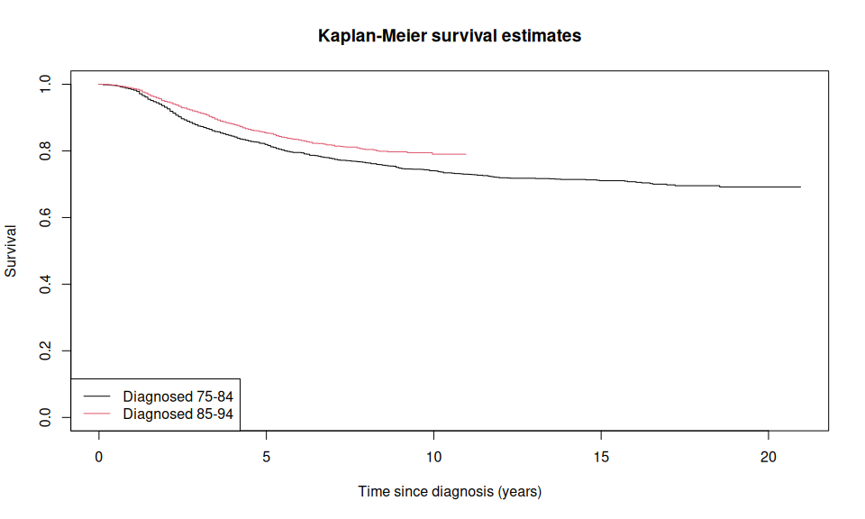

```r
survfit(Surv(surv_mm/12, death_cancer==1) ~ year8594, data = melanoma) |>
    plot(col = 1:2,
         xlab = "Time since diagnosis (years)",
         ylab = "Survival",
         main = "Kaplan-Meier survival estimates")
legend("bottomleft", levels(melanoma$year8594), col=1:2, lty = 1)
```

There seems to be a clear difference in survival between the two periods. Patients diagnosed during 1985–94 have superior survival to those diagnosed 1975–84.

## (b)

The plot of the hazard clearly illustrates the pattern of cancer-specific mortality as a function of time whereas this pattern is not obvious in the plot of the survivor function.

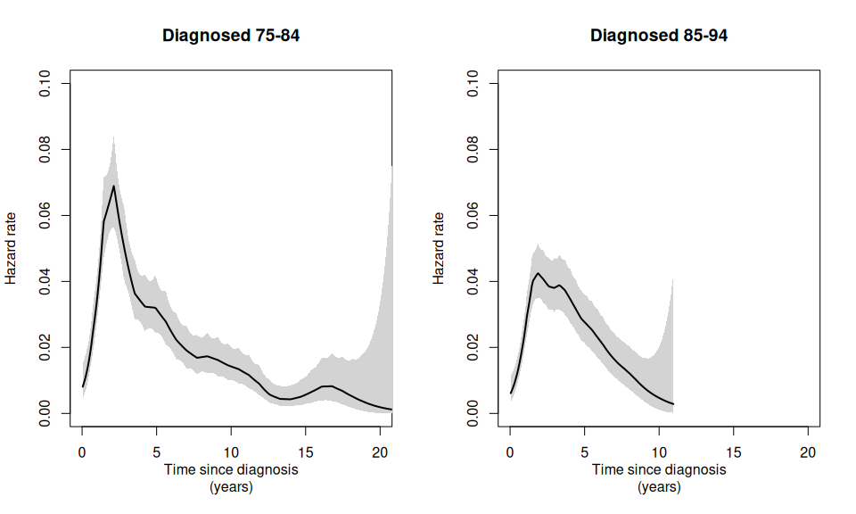

```r
par(mfrow=1:2)
for(level in levels(melanoma$year8594))
    plot(bshazard(Surv(surv_mm/12,death_cancer)~1, subset(melanoma,year8594==level),
                  verbose=FALSE), main=level, xlim=c(0,20), ylim=c(0,0.1),
         xlab="Time since diagnosis\n(years)")
```

## (c)

There is strong evidence that survival differs between the two periods. The log-rank and the Wilcoxon tests give very similar results. The Wilcoxon test gives more weight to differences in survival in the early period of follow-up (where there are more individuals at risk) whereas the log rank test gives equal weight to all points in the follow-up. Both tests assume that, if there is a difference, a proportional hazards assumption is appropriate.

```r
## Log-rank test for equality of survivor functions
survdiff(Surv(surv_mm, death_cancer) ~ year8594, data=melanoma)
```

```
## Call:
## survdiff(formula = Surv(surv_mm, death_cancer) ~ year8594, data = melanoma)
##
##                             N Observed Expected (O-E)^2/E (O-E)^2/V
## year8594=Diagnosed 75-84 2145      572      512      7.03      15.5
## year8594=Diagnosed 85-94 3173      441      501      7.18      15.5
##
##  Chisq= 15.5  on 1 degrees of freedom, p= 8e-05
```

```r
## Equivalent to the Peto & Peto modfication of the Gehan-Wilcoxon test
survdiff(Surv(surv_mm, death_cancer) ~ year8594, data=melanoma, rho=1)
```

```
## Call:
## survdiff(formula = Surv(surv_mm, death_cancer) ~ year8594, data = melanoma,
##     rho = 1)
##
##                             N Observed Expected (O-E)^2/E (O-E)^2/V
## year8594=Diagnosed 75-84 2145      502      447      6.82      16.2
## year8594=Diagnosed 85-94 3173      400      455      6.70      16.2
##
##  Chisq= 16.2  on 1 degrees of freedom, p= 6e-05
```

## (d)

We see that mortality increases with age at diagnosis (and survival decreases).

```r
survRate(Surv(surv_mm/1000,death_cancer)~agegrp, data=melanoma)
```

```
##              agegrp    tstop event     rate    lower    upper
## agegrp=0-44    0-44 157.1215   217 1.381097 1.203441 1.577593
## agegrp=45-59  45-59 148.8215   282 1.894887 1.680159 2.129453
## agegrp=60-74  60-74 121.3380   333 2.744400 2.457518 3.055574
## agegrp=75+      75+  36.2380   181 4.994757 4.293585 5.777786
```

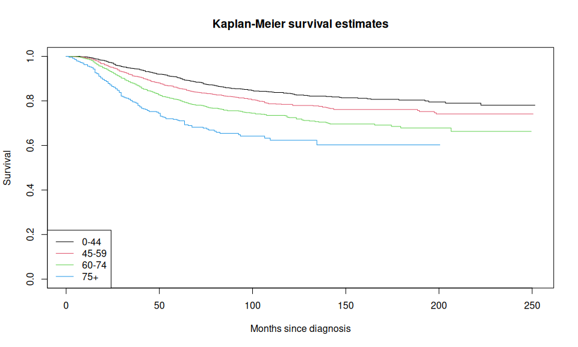

```r
## melanoma |>
##     select(death_cancer, surv_mm, year8594) |>
##     group_by(year8594) |>
##     summarise(D = sum(death_cancer), Y = sum(surv_mm)/1000, Rate = D/Y,
##               lower.ci = stats::poisson.test(D,Y)$conf.int[1],
##               upper.ci = stats::poisson.test(D,Y)$conf.int[2])

survfit(Surv(surv_mm, death_cancer) ~ agegrp, data = melanoma) |>
    plot(col = 1:4,
         xlab = "Months since diagnosis",
         ylab = "Survival",
         main = "Kaplan-Meier survival estimates")
legend("bottomleft", levels(melanoma$agegrp), col=1:4, lty = 1)
```

What are the units of the estimated hazard rates? HINT: look at how you defined time.

## (e)

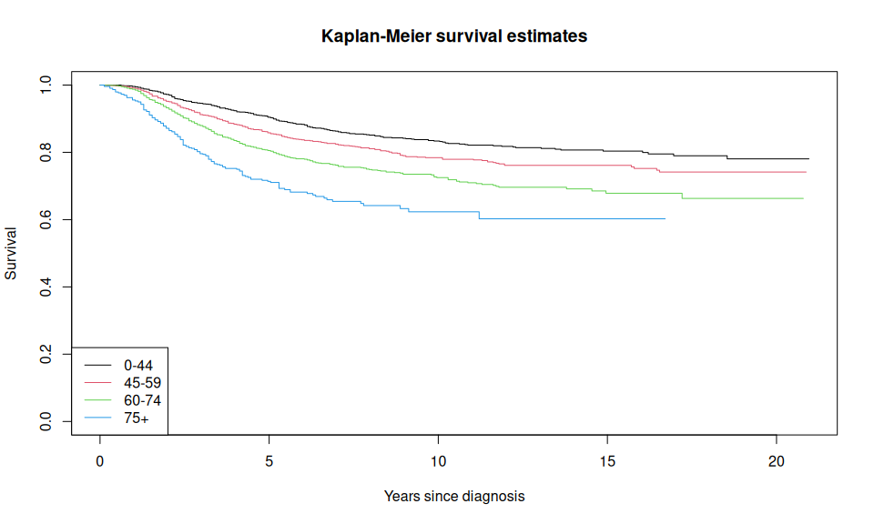

```r
survfit(Surv(surv_mm/12, death_cancer) ~ agegrp, data = melanoma) |>
    plot(col = 1:4,
         xlab = "Years since diagnosis",
         ylab = "Survival",
         main = "Kaplan-Meier survival estimates")
legend("bottomleft", levels(melanoma$agegrp), col=1:4, lty = 1)
```

```r
survRate(Surv(surv_mm/12/1000,death_cancer)~year8594, data=melanoma)
```

```
##                                 year8594    tstop event     rate    lower    upper
## year8594=Diagnosed 75-84 Diagnosed 75-84 22.66279   572 25.23961 23.21332 27.39540
## year8594=Diagnosed 85-94 Diagnosed 85-94 15.96379   441 27.62502 25.10656 30.32768
```

## (f)

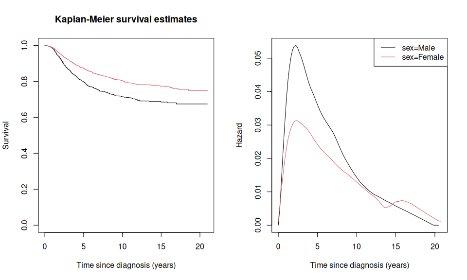

```r
aplot = function() {
    survfit(Surv(surv_mm/12, death_cancer) ~ sex, data = melanoma) |>
    plot(col = 1:2,
         xlab = "Time since diagnosis (years)",
         ylab = "Survival",
         main = "Kaplan-Meier survival estimates")
}
if (requireNamespace("muhaz", quietly=TRUE)) {
    par(mfrow=c(1, 2))
    aplot()
    plot(muhaz2(Surv(surv_mm/12,death_cancer)~sex, data=melanoma), lty=1,
         xlab="Time since diagnosis (years)")
} else {
    par(mfrow=c(1, 1))
    aplot()
    legend("bottomleft", legend=levels(melanoma$sex), lty=1, col=1:2)
}
```

```r
## Log-rank test for equality of survivor functions
survdiff(Surv(surv_mm, death_cancer==1) ~ sex, data=melanoma)
```

```
## Call:
## survdiff(formula = Surv(surv_mm, death_cancer == 1) ~ sex, data = melanoma)
##
##               N Observed Expected (O-E)^2/E (O-E)^2/V
## sex=Male   2405      542      433      27.7      48.6
## sex=Female 2913      471      580      20.6      48.6
##
##  Chisq= 48.6  on 1 degrees of freedom, p= 3e-12
```